# Introduction to hicream

Elise Jorge, Sylvain Foissac, Pierre Neuvial, et Nathalie Vialaneix

2026-01-30

# Introduction

`hicream` is an **R** package designed to perform Hi-c data differential analysis. More specifically, it performs a pixel-level differential analysis using `diffHic` and, using a two-dimensional connectivity constrained clustering, renders a post hoc bound on True Discovery Proportion for each cluster. This method allows to identify differential genomic regions and quantifies signal in those regions.

```r
library("hicream", warn.conflicts = FALSE)
# checking if Python and Python modules are available to avoid errors in vignette building
modules_avail <- reticulate::py_available(initialize = TRUE) &&
  reticulate::py_module_available("sklearn") &&
  reticulate::py_module_available("kneebow") &&
  reticulate::py_module_available("pandas") &&
  reticulate::py_module_available("numpy")
```

## How to load external data?

Using `hicream` requires to load data that corresponds to Hi-C matrices and their index, the latter in bed format. In the following code, the paths to Hi-C matrices and the index file path are used in the `loadData` function alongside the chromosome number. The option `normalize = TRUE` allows to perform a cyclic LOESS normalization. The output is an `InteractionSet` object.

```r
replicates <- 1:2
cond <- "90"
allBegins <- interaction(expand.grid(replicates, cond), sep = "-")
allBegins <- as.character(allBegins)
chromosome <- 1
nbChr <- 1
allMat <- sapply(allBegins, function(ab) {
  matFile <- paste0("Rep", ab, "-chr", chromosome, "_200000.bed")
})
index <- system.file("extdata", "index.200000.longest18chr.abs.bed",
                     package = "hicream")
format <- rep("HiC-Pro", length(replicates) * length(cond) * nbChr)
binsize <- 200000
files <- system.file("extdata", unlist(allMat), package = "hicream")
exData <- loadData(files, index, chromosome, normalize = TRUE)
```

```
##  chr(0)
```

```
##  chr(0)
```

## `pighic` dataset

The `pighic` dataset has been produced using 6 Hi-C matrices (3 in each condition) obtained from two different developmental stages of pig embryos (90 and 110 days of gestation) corresponding to chromosome 1. The dataset contains two elements, the first is an output of the `loadData` function corresponding to normalized data. The second is the vector giving, for each matrix, the condition it belongs to.

```r
data("pighic")
head(pighic)
```

```
## $data
## class: InteractionSet
## dim: 21 6
## metadata(1): width
## assays(2): counts offset
## rownames: NULL
## rowData names(2): anchor1.id anchor2.id
## colnames: NULL
## colData names(1): totals
## type: ReverseStrictGInteractions
## regions: 6
##
## $conditions
## [1] "90"  "90"  "90"  "110" "110" "110"
```

# Perform `hicream` test

Once data have been loaded, the three steps of the analysis can be performed.

## Use `performTest` function

In this first step, the output of a `loadData` object is used, with a vector indicating the condition of each sample. Here, we use data stored in `pighic`. `performTest` outputs the result of the `diffHic` pixel-level differential analysis.

```r
resdiff <- performTest(pighic$data, pighic$conditions)
resdiff
```

```
## Testing for differential interactions using diffHic.
##
##   region1 region2   p.value     p.adj       logFC
## 1    1125    1125 0.7318482 0.8538229 -0.01830721
## 2    1125    1126 0.0562111 0.2342558 -0.16338780
##  [ reached 'max' / getOption("max.print") -- omitted 19 rows ]
```

```r
summary(resdiff)
```

```
## Summary of diffHic results.
```

```
##     p.value              p.adj              logFC
##  Min.   :0.0002064   Min.   :0.004334   Min.   :-0.163388
##  1st Qu.:0.0669302   1st Qu.:0.234256   1st Qu.:-0.034500
##  Median :0.2751093   Median :0.525209   Median : 0.003099
##  Mean   :0.3960997   Mean   :0.580792   Mean   : 0.022271
##  3rd Qu.:0.6924986   3rd Qu.:0.853823   3rd Qu.: 0.040991
##  Max.   :0.9537715   Max.   :0.953771   Max.   : 0.349596
```

Several plotting options allow to look at the $p$-value map, adjusted $p$-value map or log-fold-change map.

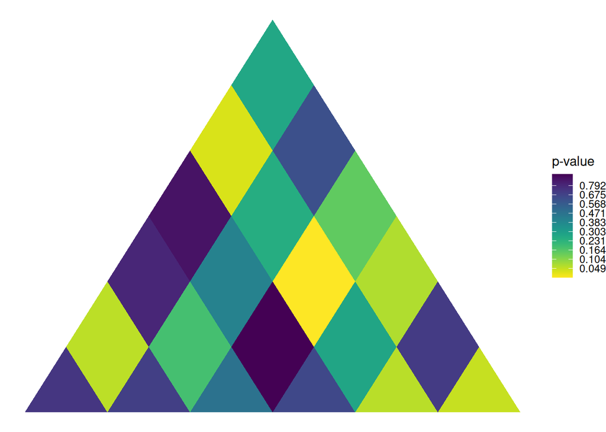

```r
plot(resdiff)
```

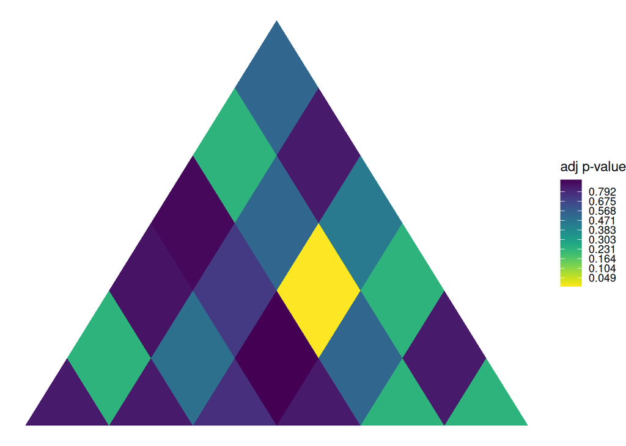

```r
plot(resdiff, whichPlot = "p.adj")
```

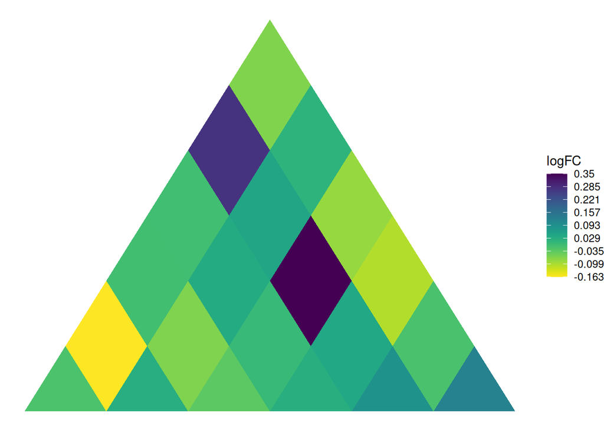

```r
plot(resdiff, whichPlot = "logFC")
```

## Perform two-dimensional connectivity-constrained clustering

The `AggloClust2D` function uses either the output of `loadData` or `resdiff` functions. If the output of `loadData` is used, the clustering is performed on the counts. Using the output of `resdiff` amounts to performing clustering on adjusted $p$-values and log-fold-changes.

In both cases, a connectivity graph of pixels is built and a two-dimensional hierarchical clustering under the connectivity constraint is performed. The function renders a clustering corresponding to the optimal number of clusters found by the elbow heuristic. However, a clustering corresponding to any other number of clusters (chosen by the user) can be obtained by specifying a value for the input argument `nbClust`.

```r
if (modules_avail) {
  res2D_counts <- AggloClust2D(pighic$data)
  res2D_counts
  summary(res2D_counts)
}
```

```
## Summary of 2D constrained clustering results.
```

```
##
## Call:
## AggloClust2D(pighic$data)
##
## Cluster method   : Constrained HC with Ward linkage from sklearn
## Distance         : euclidean
## Number of objects: 21
```

```r
if (modules_avail) {
  res2D_diff <- AggloClust2D(resdiff)
  res2D_diff
  summary(res2D_diff)
}
```

```
## Summary of 2D constrained clustering results.
```

```
##
## Call:
## AggloClust2D(resdiff)
##
## Cluster method   : Constrained HC with Ward linkage from sklearn
## Distance         : euclidean
## Number of objects: 21
```

Plotting the output shows the tree that corresponds to the hierarchy of clusters.

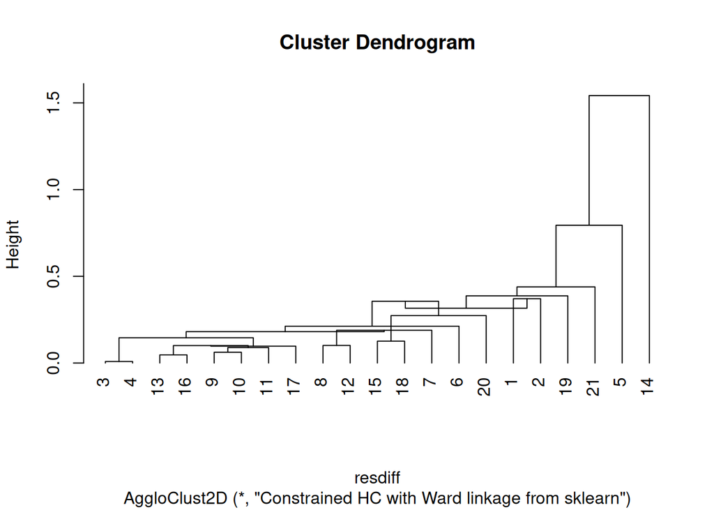

```r
if (modules_avail) {
  plot(res2D_diff)
}
```

## Perform post hoc inference

Post hoc inference is performed by the `postHoc` function, using the output of `performTest`, and a clustering (the latter can be obtained with `AggloClust2D`). The user sets a level of test confidence $\alpha$, typically equal to $0.05$.

```r
if (modules_avail) {
  clusters <- res2D_diff$clustering
  alpha <- 0.05
  resposthoc <- postHoc(resdiff, clusters, alpha)
  resposthoc
  summary(resposthoc)
}
```

```
## Summary of post hoc results.
```

```
##       TDP             p.value              p.adj              logFC
##  Min.   :0.00000   Min.   :0.0002064   Min.   :0.004334   Min.   :-0.163388
##  1st Qu.:0.00000   1st Qu.:0.0669302   1st Qu.:0.234256   1st Qu.:-0.034500
##  Median :0.00000   Median :0.2751093   Median :0.525209   Median : 0.003099
##  Mean   :0.04762   Mean   :0.3960997   Mean   :0.580792   Mean   : 0.022271
##  3rd Qu.:0.00000   3rd Qu.:0.6924986   3rd Qu.:0.853823   3rd Qu.: 0.040991
##  Max.   :1.00000   Max.   :0.9537715   Max.   :0.953771   Max.   : 0.349596
##   propPoslogFC
##  Min.   :0.4737
##  1st Qu.:0.4737
##  Median :0.4737
##  Mean   :0.5238
##  3rd Qu.:0.4737
##  Max.   :1.0000
```

Plotting the output of `postHoc` function shows the minimal proportion of True Discoveries in each cluster.

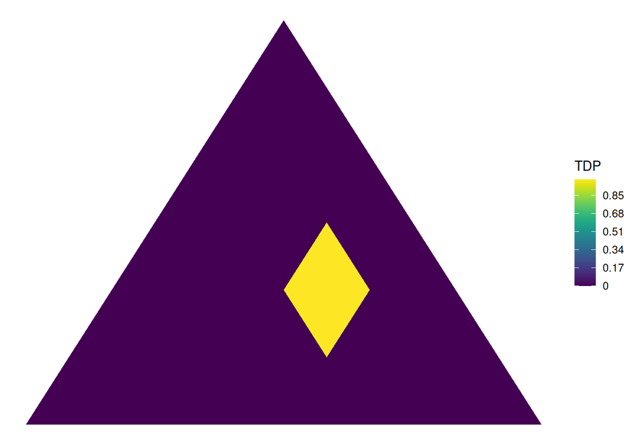

```r
if (modules_avail) plot(resposthoc)
```